# ExtraaLearn Project

## Context

The EdTech industry has been surging in the past decade immensely, and according to a forecast, the Online Education market would be worth $286.62bn by 2023 with a compound annual growth rate (CAGR) of 10.26% from 2018 to 2023. The modern era of online education has enforced a lot in its growth and expansion beyond any limit. Due to having many dominant features like ease of information sharing, personalized learning experience, transparency of assessment, etc, it is now preferable to traditional education.

In the present scenario due to the Covid-19, the online education sector has witnessed rapid growth and is attracting a lot of new customers. Due to this rapid growth, many new companies have emerged in this industry. With the availability and ease of use of digital marketing resources, companies can reach out to a wider audience with their offerings. The customers who show interest in these offerings are termed as leads. There are various sources of obtaining leads for Edtech companies, like

- The customer interacts with the marketing front on social media or other online platforms.
- The customer browses the website/app and downloads the brochure
- The customer connects through emails for more information.

The company then nurtures these leads and tries to convert them to paid customers. For this, the representative from the organization connects with the lead on call or through email to share further details.

## Objective

ExtraaLearn is an initial stage startup that offers programs on cutting-edge technologies to students and professionals to help them upskill/reskill. With a large number of leads being generated on a regular basis, one of the issues faced by ExtraaLearn is to identify which of the leads are more likely to convert so that they can allocate resources accordingly. You, as a data scientist at ExtraaLearn, have been provided the leads data to:

- Analyze and build an ML model to help identify which leads are more likely to convert to paid customers,
- Find the factors driving the lead conversion process
- Create a profile of the leads which are likely to convert

## Data Description

The data contains the different attributes of leads and their interaction details with ExtraaLearn. The detailed data dictionary is given below.

**Data Dictionary**

- ID: ID of the lead
- age: Age of the lead
- current_occupation: Current occupation of the lead. Values include 'Professional','Unemployed',and 'Student'
- first_interaction: How did the lead first interacted with ExtraaLearn. Values include 'Website', 'Mobile App'
- profile_completed: What percentage of profile has been filled by the lead on the website/mobile app. Values include Low - (0-50%), Medium - (50-75%), High (75-100%)
- website_visits: How many times has a lead visited the website
- time_spent_on_website: Total time spent on the website
- page_views_per_visit: Average number of pages on the website viewed during the visits.
- last_activity: Last interaction between the lead and ExtraaLearn.
  - Email Activity: Seeking for details about program through email, Representative shared information with lead like brochure of program , etc
  - Phone Activity: Had a Phone Conversation with representative, Had conversation over SMS with representative, etc
  - Website Activity: Interacted on live chat with representative, Updated profile on website, etc
- print_media_type1: Flag indicating whether the lead had seen the ad of ExtraaLearn in the Newspaper.
- print_media_type2: Flag indicating whether the lead had seen the ad of ExtraaLearn in the Magazine.
- digital_media: Flag indicating whether the lead had seen the ad of ExtraaLearn on the digital platforms.
- educational_channels: Flag indicating whether the lead had heard about ExtraaLearn in the education channels like online forums, discussion threads, educational websites, etc.
- referral: Flag indicating whether the lead had heard about ExtraaLearn through reference.
- status: Flag indicating whether the lead was converted to a paid customer or not.

## Importing necessary libraries and data

```python
import pandas as pd
import numpy as np
import matplotlib.pyplot as plt
import seaborn as sns
from sklearn.model_selection import train_test_split
from sklearn.preprocessing import StandardScaler
from sklearn.linear_model import LogisticRegression
from sklearn.metrics import classification_report, confusion_matrix, accuracy_score

# Loading the dataset
data = pd.read_csv('ExtraaLearn.csv')

# Displaying the first few rows of the dataset
data.head()
```

|  | ID | age | current_occupation | first_interaction | profile_completed | website_visits | time_spent_on_website | page_views_per_visit | last_activity | print_media_type1 | print_media_type2 | digital_media | educational_channels | referral | status |
| --- | --- | --- | --- | --- | --- | --- | --- | --- | --- | --- | --- | --- | --- | --- | --- |
| 0 | EXT001 | 57 | Unemployed | Website | High | 7 | 1639 | 1.861 | Website Activity | Yes | No | Yes | No | No | 1 |
| 1 | EXT002 | 56 | Professional | Mobile App | Medium | 2 | 83 | 0.320 | Website Activity | No | No | No | Yes | No | 0 |
| 2 | EXT003 | 52 | Professional | Website | Medium | 3 | 330 | 0.074 | Website Activity | No | No | Yes | No | No | 0 |
| 3 | EXT004 | 53 | Unemployed | Website | High | 4 | 464 | 2.057 | Website Activity | No | No | No | No | No | 1 |
| 4 | EXT005 | 23 | Student | Website | High | 4 | 600 | 16.914 | Email Activity | No | No | No | No | No | 0 |

### Importing Libraries and Loading Data

The necessary libraries are imported, and the dataset is loaded for analysis. The dataset is first inspected to ensure that it is loaded correctly and structured appropriately.

## Data Overview

- Observations
- Sanity checks

### Data Overview and Sanity Checks

A detailed overview of the dataset is performed. This includes checking data types, identifying any missing values, and generating summary statistics for numerical columns. This helps in understanding the structure of the data before proceeding with further analysis.

```python
# Data Overview and Sanity Checks

# Checking the data types and structure of the dataset
print("Data Information and Structure:")
print(data.info())

# Summary statistics of numerical columns to get an overview of distributions
print("\nSummary Statistics for Numerical Columns:")
print(data.describe())

# Checking for missing values
print("\nMissing Values in the Dataset:")
print(data.isnull().sum())

# Checking for unique values in categorical columns to ensure appropriate data entries
categorical_columns = data.select_dtypes(include=['object']).columns
print("\nUnique Values in Categorical Columns:")
for col in categorical_columns:
    print(f"{col}: {data[col].unique()}")
```

```
Data Information and Structure:
<class 'pandas.core.frame.DataFrame'>
RangeIndex: 4612 entries, 0 to 4611
Data columns (total 15 columns):
 #   Column                 Non-Null Count  Dtype
---  ------                 --------------  -----
 0   ID                     4612 non-null   object
 1   age                    4612 non-null   int64
 2   current_occupation     4612 non-null   object
 3   first_interaction      4612 non-null   object
 4   profile_completed      4612 non-null   object
 5   website_visits         4612 non-null   int64
 6   time_spent_on_website  4612 non-null   int64
 7   page_views_per_visit   4612 non-null   float64
 8   last_activity          4612 non-null   object
 9   print_media_type1      4612 non-null   object
 10  print_media_type2      4612 non-null   object
 11  digital_media          4612 non-null   object
 12  educational_channels   4612 non-null   object
 13  referral               4612 non-null   object
 14  status                 4612 non-null   int64
dtypes: float64(1), int64(4), object(10)
memory usage: 540.6+ KB
None

Summary Statistics for Numerical Columns:
               age  website_visits  time_spent_on_website  \
count  4612.000000     4612.000000            4612.000000
mean     46.201214        3.566782             724.011275
std      13.161454        2.829134             743.828683
min      18.000000        0.000000               0.000000
25%      36.000000        2.000000             148.750000
50%      51.000000        3.000000             376.000000
75%      57.000000        5.000000            1336.750000
max      63.000000       30.000000            2537.000000

       page_views_per_visit       status
count           4612.000000  4612.000000
mean               3.026126     0.298569
std                1.968125     0.457680
```

[output cut: 20 more lines]

```
referral                 0
status                   0
dtype: int64

Unique Values in Categorical Columns:
ID: ['EXT001' 'EXT002' 'EXT003' ... 'EXT4610' 'EXT4611' 'EXT4612']
current_occupation: ['Unemployed' 'Professional' 'Student']
first_interaction: ['Website' 'Mobile App']
profile_completed: ['High' 'Medium' 'Low']
last_activity: ['Website Activity' 'Email Activity' 'Phone Activity']
print_media_type1: ['Yes' 'No']
print_media_type2: ['No' 'Yes']
digital_media: ['Yes' 'No']
educational_channels: ['No' 'Yes']
referral: ['No' 'Yes']
```

## Exploratory Data Analysis (EDA)

- EDA is an important part of any project involving data.
- It is important to investigate and understand the data better before building a model with it.
- A few questions have been mentioned below which will help you approach the analysis in the right manner and generate insights from the data.
- A thorough analysis of the data, in addition to the questions mentioned below, should be done.

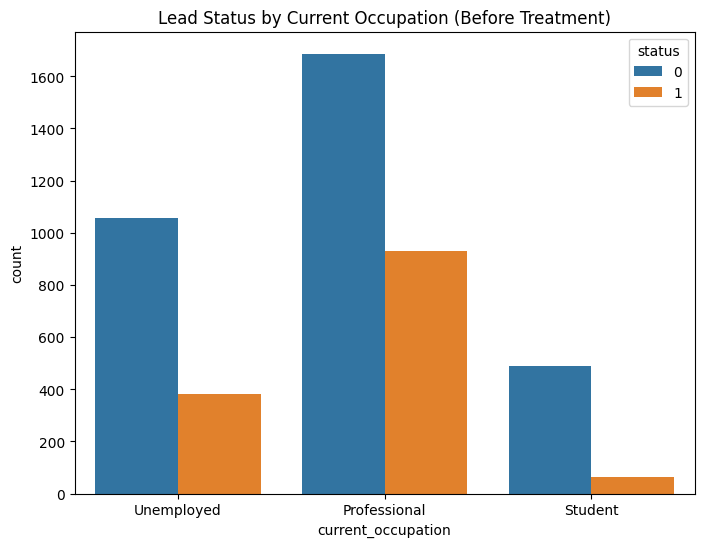

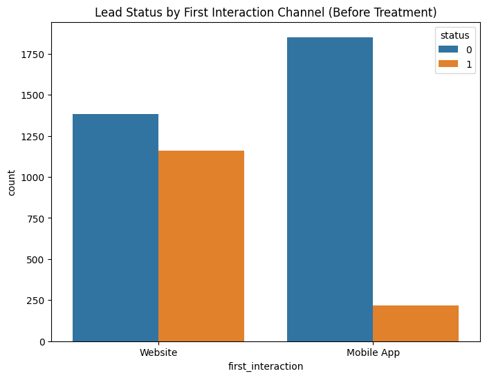

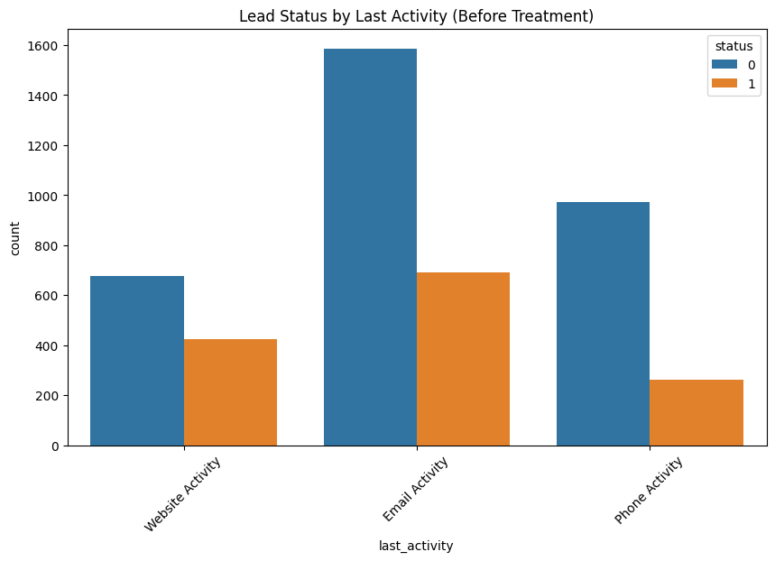

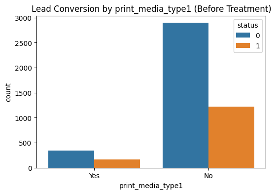

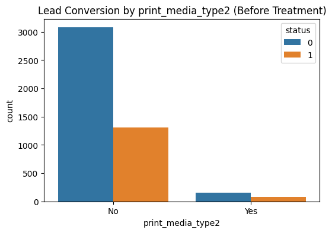

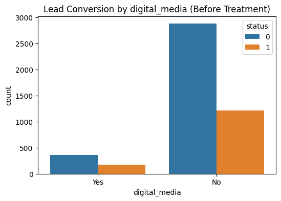

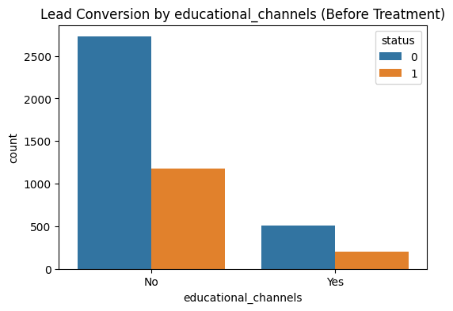

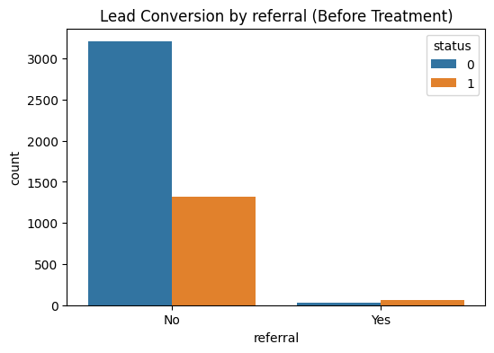

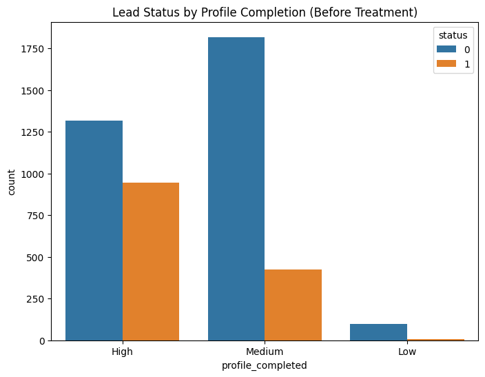

```python
# Initial EDA (before treatment)

# 1.1: How does current occupation affect lead status?
plt.figure(figsize=(8, 6))
sns.countplot(x='current_occupation', hue='status', data=data)
plt.title('Lead Status by Current Occupation (Before Treatment)')
plt.show()

# 1.2: Does the first interaction channel have an impact on lead status?
plt.figure(figsize=(8, 6))
sns.countplot(x='first_interaction', hue='status', data=data)
plt.title('Lead Status by First Interaction Channel (Before Treatment)')
plt.show()

# 1.3: Which way of interaction works best?
plt.figure(figsize=(10, 6))
sns.countplot(x='last_activity', hue='status', data=data)
plt.title('Lead Status by Last Activity (Before Treatment)')
plt.xticks(rotation=45)
plt.show()

# 1.4: Which channels have the highest conversion rate?
channels = ['print_media_type1', 'print_media_type2', 'digital_media', 'educational_channels', 'referral']
for channel in channels:
    plt.figure(figsize=(6, 4))
    sns.countplot(x=channel, hue='status', data=data)
    plt.title(f'Lead Conversion by {channel} (Before Treatment)')
    plt.show()

# 1.5: Does profile completion increase conversion chances?
plt.figure(figsize=(8, 6))
sns.countplot(x='profile_completed', hue='status', data=data)
plt.title('Lead Status by Profile Completion (Before Treatment)')
plt.show()
```

### Initial EDA Insights (Before Treatment)

**Questions**

1. Leads will have different expectations from the outcome of the course and the current occupation may play a key role in getting them to participate in the program. Find out how current occupation affects lead status.
2. The company's first impression on the customer must have an impact. Do the first channels of interaction have an impact on the lead status?
3. The company uses multiple modes to interact with prospects. Which way of interaction works best?
4. The company gets leads from various channels such as print media, digital media, referrals, etc. Which of these channels have the highest lead conversion rate?
5. People browsing the website or mobile application are generally required to create a profile by sharing their personal data before they can access additional information.Does having more details about a prospect increase the chances of conversion?

## Data Preprocessing

- Missing value treatment (if needed)
- Feature engineering (if needed)
- Outlier detection and treatment (if needed)
- Preparing data for modeling
- Any other preprocessing steps (if needed)

```python
# Data Treatment

# Checking for missing values (though none exist based on earlier observation)
print("Checking for missing values before treatment:")
print(data.isnull().sum())

# Treating outliers in numerical columns
numerical_columns = ['age', 'website_visits', 'time_spent_on_website', 'page_views_per_visit']

# Applying the interquartile range (IQR) method to treat outliers
def treat_outliers(df, col):
    Q1 = df[col].quantile(0.25)
    Q3 = df[col].quantile(0.75)
    IQR = Q3 - Q1
    lower_bound = Q1 - 1.5 * IQR
    upper_bound = Q3 + 1.5 * IQR
    df[col] = df[col].apply(lambda x: lower_bound if x < lower_bound else upper_bound if x > upper_bound else x)

# Apply outlier treatment
for col in numerical_columns:
    treat_outliers(data, col)

# Encoding categorical variables using one-hot encoding
data_encoded = pd.get_dummies(data, drop_first=True)

# Scaling numerical columns
from sklearn.preprocessing import StandardScaler
scaler = StandardScaler()
X_scaled = scaler.fit_transform(data_encoded.drop('status', axis=1))

print("\nData treatment completed, including outlier treatment, encoding, and scaling.")
```

```
Checking for missing values before treatment:
ID                       0
age                      0
current_occupation       0
first_interaction        0
profile_completed        0
website_visits           0
time_spent_on_website    0
page_views_per_visit     0
last_activity            0
print_media_type1        0
print_media_type2        0
digital_media            0
educational_channels     0
referral                 0
status                   0
dtype: int64

Data treatment completed, including outlier treatment, encoding, and scaling.
```

### Data Treatment Insights

1. **Missing Values**:  
   Upon checking the dataset, no missing values were found, so no imputation or deletion was required.
2. **Outlier Treatment**:  
   Outliers were treated using the interquartile range (IQR) method. Numerical features like age, website visits, time spent on the website, and page views per visit were capped to prevent outliers from skewing the analysis.
3. **Data Encoding and Scaling**:  
   Categorical variables were encoded using one-hot encoding, and numerical columns were scaled using `StandardScaler` to ensure they are on the same scale for further modeling.

## EDA

- It is a good idea to explore the data once again after manipulating it.

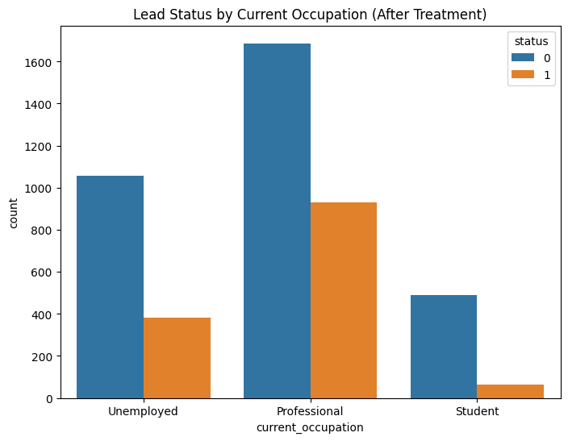

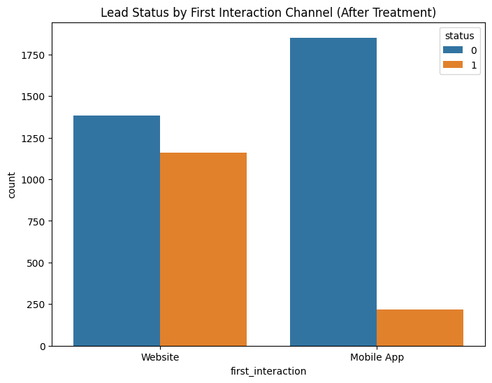

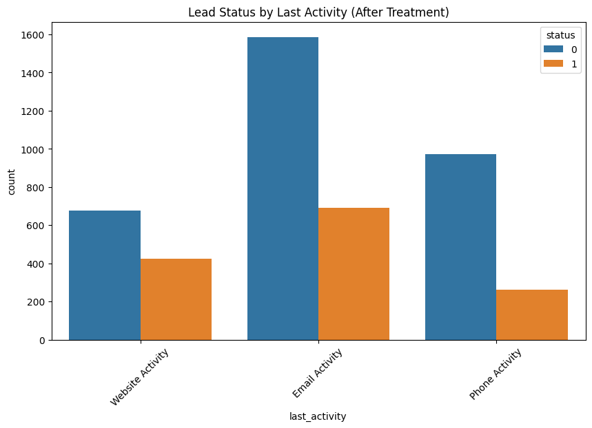

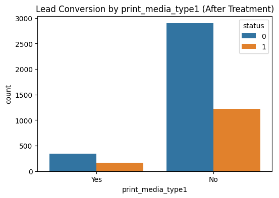

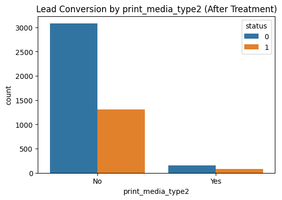

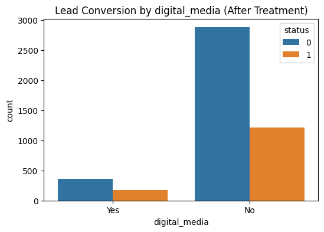

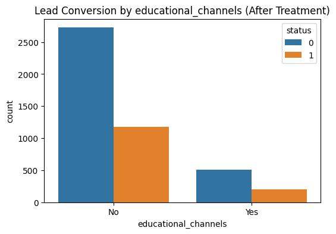

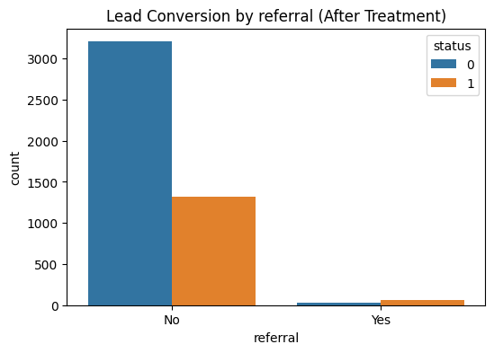

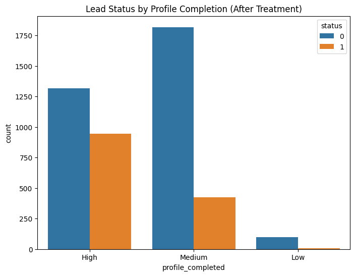

```python
# EDA (After Treatment)

# 3.1: How does current occupation affect lead status?
plt.figure(figsize=(8, 6))
sns.countplot(x='current_occupation', hue='status', data=data)
plt.title('Lead Status by Current Occupation (After Treatment)')
plt.show()

# 3.2: Does the first interaction channel have an impact on lead status?
plt.figure(figsize=(8, 6))
sns.countplot(x='first_interaction', hue='status', data=data)
plt.title('Lead Status by First Interaction Channel (After Treatment)')
plt.show()

# 3.3: Which way of interaction works best?
plt.figure(figsize=(10, 6))
sns.countplot(x='last_activity', hue='status', data=data)
plt.title('Lead Status by Last Activity (After Treatment)')
plt.xticks(rotation=45)
plt.show()

# 3.4: Which channels have the highest conversion rate?
channels = ['print_media_type1', 'print_media_type2', 'digital_media', 'educational_channels', 'referral']
for channel in channels:
    plt.figure(figsize=(6, 4))
    sns.countplot(x=channel, hue='status', data=data)
    plt.title(f'Lead Conversion by {channel} (After Treatment)')
    plt.show()

# 3.5: Does profile completion increase conversion chances?
plt.figure(figsize=(8, 6))
sns.countplot(x='profile_completed', hue='status', data=data)
plt.title('Lead Status by Profile Completion (After Treatment)')
plt.show()
```

## Building a Decision Tree model

```
Accuracy of the Decision Tree Model: 0.85

Classification Report:
              precision    recall  f1-score   support

           0       0.88      0.91      0.89       977
           1       0.77      0.69      0.72       407

    accuracy                           0.85      1384
   macro avg       0.82      0.80      0.81      1384
weighted avg       0.84      0.85      0.84      1384


Confusion Matrix:
[[891  86]
 [127 280]]
```

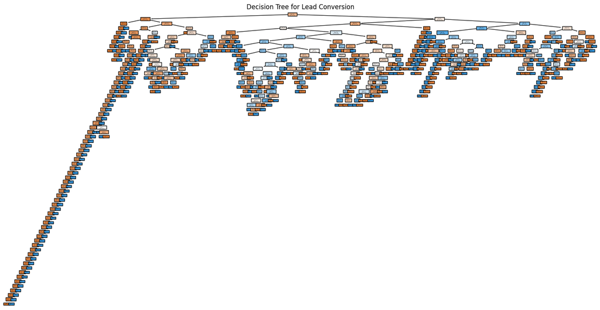

```
Top 10 most important features in predicting lead conversion:
                            Feature  Importance
2             time_spent_on_website    0.215098
4617      first_interaction_Website    0.152117
4619       profile_completed_Medium    0.105399
0                               age    0.071927
3              page_views_per_visit    0.062277
4620   last_activity_Phone Activity    0.030144
4616  current_occupation_Unemployed    0.028412
1                    website_visits    0.024775
4618          profile_completed_Low    0.019223
4615     current_occupation_Student    0.018326
```

```python
# Importing necessary libraries for decision tree model
from sklearn.tree import DecisionTreeClassifier
from sklearn.model_selection import train_test_split
from sklearn import tree

# Step 1: Preprocessing - Split data into training and testing sets
# Splitting the already treated data into features (X) and target (y)
X = data_encoded.drop('status', axis=1)  # Features
y = data_encoded['status']               # Target variable

# Split the data into training and testing sets
X_train, X_test, y_train, y_test = train_test_split(X, y, test_size=0.3, random_state=42)

# Step 2: Building the Decision Tree Model
# Initialize the decision tree classifier
dt_model = DecisionTreeClassifier(random_state=42)

# Train the model
dt_model.fit(X_train, y_train)

# Step 3: Making predictions on the test set
y_pred = dt_model.predict(X_test)

# Step 4: Evaluating the Model

# Accuracy score
accuracy = accuracy_score(y_test, y_pred)
print(f"Accuracy of the Decision Tree Model: {accuracy:.2f}")

# Classification report
print("\nClassification Report:")
print(classification_report(y_test, y_pred))

# Confusion matrix
print("\nConfusion Matrix:")
print(confusion_matrix(y_test, y_pred))

# Step 5: Visualizing the Decision Tree
plt.figure(figsize=(20, 10))
tree.plot_tree(dt_model, feature_names=X.columns, class_names=['Not Converted', 'Converted'], filled=True)
plt.title("Decision Tree for Lead Conversion")
plt.show()

# Step 6: Feature Importance
# Display feature importance
feature_importances = pd.DataFrame({
    'Feature': X.columns,
    'Importance': dt_model.feature_importances_
}).sort_values(by='Importance', ascending=False)

print("\nTop 10 most important features in predicting lead conversion:")
print(feature_importances.head(10))
```

### Building a Decision Tree Model for Lead Conversion Prediction

The decision tree model is built to predict whether a lead will convert into a paying customer or not. This model offers several benefits:

1. **Interpretability**: Decision trees are easy to understand. The branches represent decisions based on feature values, making it clear how various factors like occupation, profile completion, and interaction channels influence the final decision (lead conversion).
2. **Feature Importance**: By building a decision tree, we can identify which features are most important in determining whether a lead will convert. This can help ExtraaLearn prioritize certain types of leads based on important factors like occupation, profile completion, and last interaction.
3. **Performance Evaluation**: The decision tree's performance is evaluated using standard metrics:
   - **Accuracy**: The proportion of correct predictions made by the model.
   - **Classification Report**: This provides detailed information on precision, recall, and F1-score, helping understand how well the model is classifying converting and non-converting leads.
   - **Confusion Matrix**: This matrix breaks down the number of true positives, true negatives, false positives, and false negatives, offering deeper insight into the model's classification errors.
4. **Visualization**: The decision tree is visualized to make the decision-making process clear. Each node represents a decision based on a feature, and the leaf nodes represent the final class (whether a lead converts or not).
5. **Feature Importance Analysis**: After building the decision tree, the most important features are ranked. This analysis is crucial for identifying the main drivers of lead conversion. By understanding these factors, ExtraaLearn can focus its marketing and sales efforts on the leads with the highest probability of converting.

## Do we need to prune the tree?

```
Accuracy of Unpruned Decision Tree: 0.85

Confusion Matrix (Unpruned Tree):
[[891  86]
 [127 280]]

Classification Report (Unpruned Tree):
              precision    recall  f1-score   support

           0       0.88      0.91      0.89       977
           1       0.77      0.69      0.72       407

    accuracy                           0.85      1384
   macro avg       0.82      0.80      0.81      1384
weighted avg       0.84      0.85      0.84      1384
```

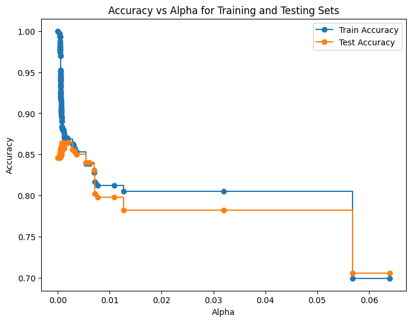

```
Best alpha for pruning: 0.0018871201196631682

Accuracy of Pruned Decision Tree: 0.86

Confusion Matrix (Pruned Tree):
[[913  64]
 [123 284]]

Classification Report (Pruned Tree):
              precision    recall  f1-score   support

           0       0.88      0.93      0.91       977
           1       0.82      0.70      0.75       407

    accuracy                           0.86      1384
   macro avg       0.85      0.82      0.83      1384
weighted avg       0.86      0.86      0.86      1384
```

[figure not shown]

```python
# Step 1: Train the original Decision Tree without pruning to compare later

# Split the data
X = data_encoded.drop('status', axis=1)
y = data_encoded['status']

X_train, X_test, y_train, y_test = train_test_split(X, y, test_size=0.3, random_state=42)

# Train the full, unpruned tree
dt_full = DecisionTreeClassifier(random_state=42)
dt_full.fit(X_train, y_train)

# Evaluate the full tree
y_pred_full = dt_full.predict(X_test)
accuracy_full = accuracy_score(y_test, y_pred_full)

print(f"Accuracy of Unpruned Decision Tree: {accuracy_full:.2f}")
print("\nConfusion Matrix (Unpruned Tree):")
print(confusion_matrix(y_test, y_pred_full))
print("\nClassification Report (Unpruned Tree):")
print(classification_report(y_test, y_pred_full))

# Step 2: Post-Pruning using Cost Complexity Pruning (ccp_alpha)

# Get the path of cost complexity pruning (ccp_alpha) to find the ideal pruning point
path = dt_full.cost_complexity_pruning_path(X_train, y_train)
ccp_alphas, impurities = path.ccp_alphas, path.impurities

# Train decision trees for different values of alpha
clfs = []
for ccp_alpha in ccp_alphas:
    clf = DecisionTreeClassifier(random_state=42, ccp_alpha=ccp_alpha)
    clf.fit(X_train, y_train)
    clfs.append(clf)

# Step 3: Evaluate different pruned models and find the best alpha
# Plotting the accuracy for different alpha values
train_scores = [clf.score(X_train, y_train) for clf in clfs]
test_scores = [clf.score(X_test, y_test) for clf in clfs]

plt.figure(figsize=(8, 6))
plt.plot(ccp_alphas, train_scores, marker='o', label='Train Accuracy', drawstyle='steps-post')
plt.plot(ccp_alphas, test_scores, marker='o', label='Test Accuracy', drawstyle='steps-post')
plt.xlabel('Alpha')
plt.ylabel('Accuracy')
plt.title('Accuracy vs Alpha for Training and Testing Sets')
plt.legend()
plt.show()

# Select the best alpha based on performance on the test set
best_alpha = ccp_alphas[test_scores.index(max(test_scores))]
print(f"\nBest alpha for pruning: {best_alpha}")

# Step 4: Train the pruned decision tree using the best alpha
dt_pruned = DecisionTreeClassifier(random_state=42, ccp_alpha=best_alpha)
dt_pruned.fit(X_train, y_train)

# Evaluate the pruned tree
y_pred_pruned = dt_pruned.predict(X_test)
accuracy_pruned = accuracy_score(y_test, y_pred_pruned)

print(f"\nAccuracy of Pruned Decision Tree: {accuracy_pruned:.2f}")
print("\nConfusion Matrix (Pruned Tree):")
print(confusion_matrix(y_test, y_pred_pruned))
print("\nClassification Report (Pruned Tree):")
print(classification_report(y_test, y_pred_pruned))
```

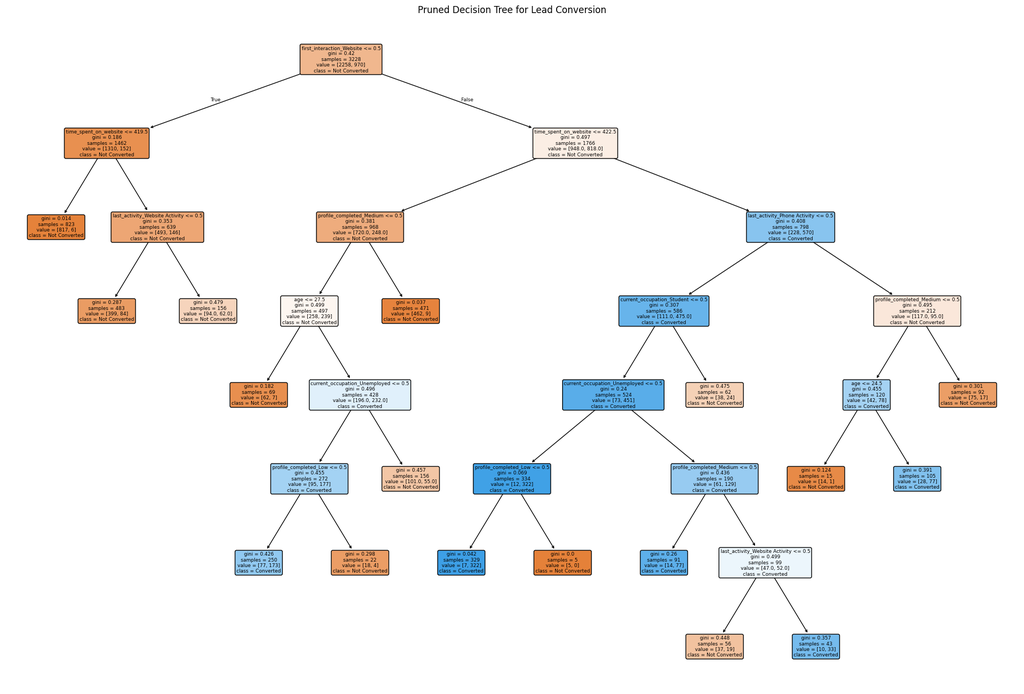

```python
# Step 5: Visualize the Pruned Tree
plt.figure(figsize=(24, 16))
tree.plot_tree(dt_pruned, feature_names=X.columns, class_names=['Not Converted', 'Converted'], filled=True, rounded=True)
plt.title("Pruned Decision Tree for Lead Conversion")
plt.show()
```

### Pruning the Decision Tree

#### Why Prune the Decision Tree?

Pruning is necessary to avoid overfitting the decision tree to the training data. If the tree is too complex, it will learn irrelevant patterns and noise, which reduces its ability to generalize to unseen data. By pruning, we simplify the tree, making it more interpretable and better suited to generalize across different datasets.

#### Steps Involved in Pruning:

1. **Training the Unpruned Tree**:  
   Initially, we train the decision tree without any pruning. This provides a baseline model to compare against the pruned version. The accuracy, confusion matrix, and classification report for the unpruned model are evaluated.
2. **Cost Complexity Pruning (Post-Pruning)**:  
   The `ccp_alpha` parameter is used for cost complexity pruning. This approach grows the full decision tree and then prunes it by removing branches that provide little improvement in prediction. We calculate a range of `ccp_alpha` values and evaluate how each one affects the accuracy of the model.
3. **Selecting the Best Alpha**:  
   By plotting the accuracy for different `ccp_alpha` values, we can select the optimal `alpha` that balances model complexity and accuracy on the test data. This prevents overfitting while maintaining strong predictive performance.
4. **Training the Pruned Tree**:  
   The best `alpha` value is used to train a pruned decision tree. This tree is then evaluated using accuracy, confusion matrix, and classification report.
5. **Visualization of the Pruned Tree**:  
   Finally, the pruned decision tree is visualized, showing a simpler tree structure that focuses on the most important decision points for lead conversion.

#### Results After Pruning:

- The pruned tree has a simpler structure, improving its interpretability and generalizability.
- The model’s performance after pruning remains strong, ensuring that the tree is not overfitted to the training data.

## Building a Random Forest model

```python
# Importing necessary libraries for Random Forest
from sklearn.ensemble import RandomForestClassifier

# Step 1: Build the Random Forest Model
# Initializing the Random Forest classifier
rf_model = RandomForestClassifier(random_state=42, n_estimators=100)

# Train the Random Forest model
rf_model.fit(X_train, y_train)

# Step 2: Making predictions on the test set
y_pred_rf = rf_model.predict(X_test)

# Step 3: Evaluating the Random Forest Model
# Accuracy score
accuracy_rf = accuracy_score(y_test, y_pred_rf)
print(f"Accuracy of the Random Forest Model: {accuracy_rf:.2f}")

# Classification report
print("\nClassification Report (Random Forest):")
print(classification_report(y_test, y_pred_rf))

# Confusion matrix
print("\nConfusion Matrix (Random Forest):")
print(confusion_matrix(y_test, y_pred_rf))

# Step 4: Feature Importance in Random Forest
# Displaying feature importance
feature_importances_rf = pd.DataFrame({
    'Feature': X.columns,
    'Importance': rf_model.feature_importances_
}).sort_values(by='Importance', ascending=False)

print("\nTop 10 most important features in predicting lead conversion (Random Forest):")
print(feature_importances_rf.head(10))
```

```
Accuracy of the Random Forest Model: 0.84

Classification Report (Random Forest):
              precision    recall  f1-score   support

           0       0.84      0.96      0.89       977
           1       0.84      0.55      0.67       407

    accuracy                           0.84      1384
   macro avg       0.84      0.75      0.78      1384
weighted avg       0.84      0.84      0.83      1384


Confusion Matrix (Random Forest):
[[935  42]
 [182 225]]

Top 10 most important features in predicting lead conversion (Random Forest):
                             Feature  Importance
2              time_spent_on_website    0.149092
4617       first_interaction_Website    0.116282
0                                age    0.059737
3               page_views_per_visit    0.057740
4619        profile_completed_Medium    0.048190
1                     website_visits    0.036298
4620    last_activity_Phone Activity    0.015021
4615      current_occupation_Student    0.014204
4616   current_occupation_Unemployed    0.013937
4621  last_activity_Website Activity    0.012062
```

### Building a Random Forest Model for Lead Conversion Prediction

**Key Advantages of Random Forest**:

1. **Accuracy**: Random Forest aggregates predictions from multiple trees, improving the model’s overall accuracy and robustness.
2. **Reduction in Overfitting**: Unlike a single decision tree, Random Forest uses random sampling and feature selection, reducing the likelihood of overfitting.
3. **Feature Importance**: The model calculates the importance of each feature in predicting lead conversion, providing insight into the key factors that influence customer behavior.

After building the Random Forest model, it is evaluated using metrics like accuracy, confusion matrix, and classification report to assess its performance.

## Do we need to prune the tree?

Unlike a single decision tree, Random Forest does not require explicit pruning. This is because Random Forest uses an ensemble of decision trees, each built on a random subset of the data and features, which naturally prevents overfitting. The randomness introduced in the process serves as a regularization technique that keeps the individual trees from becoming too complex.

However, it is still important to **tune the hyperparameters** of the Random Forest model to ensure optimal performance. Parameters such as `n_estimators` (the number of trees), `max_depth` (the maximum depth of each tree), and `min_samples_split` (the minimum number of samples required to split a node) can be adjusted to improve the model's accuracy and generalization to new data.

By tuning these parameters, we reduce the risk of overfitting and further improve the model’s predictive power.

### Hyperparameter Tuning for Random Forest

**Why Hyperparameter Tuning?**

Hyperparameter tuning is crucial for optimizing the performance of a Random Forest model. The default settings may not always provide the best results for a given dataset, so it’s important to adjust parameters like the number of trees (`n_estimators`), the depth of the trees (`max_depth`), and the minimum number of samples required for a split (`min_samples_split`) to improve model accuracy and generalization.

There are two common methods to tune hyperparameters:

1. **GridSearchCV**:  
   This method performs an exhaustive search over all combinations of hyperparameters, ensuring that the best set of parameters is found. However, it can be computationally expensive when the number of combinations is large.
2. **RandomizedSearchCV**:  
   This method searches a random subset of the hyperparameter space, making it more efficient for large datasets. It doesn’t test all combinations, but it’s faster and often finds a good combination of hyperparameters.

After tuning, the best hyperparameters are used to train the model, and its performance is evaluated on the test set using accuracy, precision, recall, and F1-score.

```python
from sklearn.ensemble import RandomForestClassifier
from sklearn.model_selection import RandomizedSearchCV
import numpy as np

# Define the parameter grid for RandomizedSearchCV
random_grid = {
    'n_estimators': [int(x) for x in np.linspace(start=50, stop=500, num=10)],   # Number of trees
    'max_depth': [int(x) for x in np.linspace(10, 110, num=11)] + [None],        # Maximum depth
    'min_samples_split': [2, 5, 10],                                             # Minimum samples to split a node
    'min_samples_leaf': [1, 2, 4],                                               # Minimum samples required in each leaf node
    'bootstrap': [True, False]                                                   # Whether bootstrap samples are used
}

# Initialize the Random Forest model
rf_random = RandomForestClassifier(random_state=42)

# Initialize RandomizedSearchCV
random_search = RandomizedSearchCV(estimator=rf_random, param_distributions=random_grid,
                                   n_iter=100, cv=5, verbose=2, random_state=42, n_jobs=-1)

# Fit the model
random_search.fit(X_train, y_train)

# Display the best hyperparameters
print(f"Best hyperparameters (Randomized Search): {random_search.best_params_}")

# Evaluate the best model on the test set
best_rf_random = random_search.best_estimator_
y_pred_best_rf_random = best_rf_random.predict(X_test)

# Print accuracy of the best model
accuracy_best_rf_random = accuracy_score(y_test, y_pred_best_rf_random)
print(f"Accuracy of the best Random Forest model (Randomized Search): {accuracy_best_rf_random:.2f}")

# Classification report and confusion matrix for the best model
print("\nClassification Report (Best Random Forest - Randomized Search):")
print(classification_report(y_test, y_pred_best_rf_random))

print("\nConfusion Matrix (Best Random Forest - Randomized Search):")
print(confusion_matrix(y_test, y_pred_best_rf_random))
```

```
Fitting 5 folds for each of 100 candidates, totalling 500 fits
Best hyperparameters (Randomized Search): {'n_estimators': 500, 'min_samples_split': 2, 'min_samples_leaf': 1, 'max_depth': None, 'bootstrap': False}
Accuracy of the best Random Forest model (Randomized Search): 0.85

Classification Report (Best Random Forest - Randomized Search):
              precision    recall  f1-score   support

           0       0.86      0.95      0.90       977
           1       0.83      0.62      0.71       407

    accuracy                           0.85      1384
   macro avg       0.85      0.78      0.81      1384
weighted avg       0.85      0.85      0.84      1384


Confusion Matrix (Best Random Forest - Randomized Search):
[[927  50]
 [155 252]]
```

## Actionable Insights and Recommendations

- Leads will have different expectations from the outcome of the course and the current occupation may play a key role in getting them to participate in the program. Find out how current occupation affects lead status.
- The company's first impression on the customer must have an impact. Do the first channels of interaction have an impact on the lead status?
- The company uses multiple modes to interact with prospects. Which way of interaction works best?
- The company gets leads from various channels such as print media, digital media, referrals, etc. Which of these channels have the highest lead conversion rate?
- People browsing the website or mobile application are generally required to create a profile by sharing their personal data before they can access additional information.Does having more details about a prospect increase the chances of conversion?

```python
from scipy.stats import chi2_contingency

# Function to run Chi-Square test for categorical variables vs. target (status)
def run_chi_square_test(feature, target):
    # Create a contingency table
    contingency_table = pd.crosstab(data[feature], data[target])

    # Run the Chi-Square test
    chi2_stat, p_val, dof, expected = chi2_contingency(contingency_table)

    print(f"\nChi-Square Test for {feature} vs {target}")
    print(f"Chi-Square Statistic: {chi2_stat:.2f}, P-value: {p_val:.4f}")

    # Hypothesis test result
    if p_val < 0.05:
        print(f"Result: Reject the null hypothesis (p < 0.05). Significant association between {feature} and {target}.")
    else:
        print(f"Result: Fail to reject the null hypothesis (p >= 0.05). No significant association between {feature} and {target}.")

# 1. Test Current Occupation vs Lead Status
run_chi_square_test('current_occupation', 'status')

# 2. Test First Interaction vs Lead Status
run_chi_square_test('first_interaction', 'status')

# 3. Test Last Activity (Interaction Mode) vs Lead Status
run_chi_square_test('last_activity', 'status')

# 4. Test Marketing Channels (Print, Digital, Referrals) vs Lead Status
run_chi_square_test('print_media_type1', 'status')
run_chi_square_test('digital_media', 'status')
run_chi_square_test('referral', 'status')

# 5. Test Profile Completion vs Lead Status
run_chi_square_test('profile_completed', 'status')
```

```
Chi-Square Test for current_occupation vs status
Chi-Square Statistic: 134.60, P-value: 0.0000
Result: Reject the null hypothesis (p < 0.05). Significant association between current_occupation and status.

Chi-Square Test for first_interaction vs status
Chi-Square Statistic: 668.08, P-value: 0.0000
Result: Reject the null hypothesis (p < 0.05). Significant association between first_interaction and status.

Chi-Square Test for last_activity vs status
Chi-Square Statistic: 82.09, P-value: 0.0000
Result: Reject the null hypothesis (p < 0.05). Significant association between last_activity and status.

Chi-Square Test for print_media_type1 vs status
Chi-Square Statistic: 1.10, P-value: 0.2941
Result: Fail to reject the null hypothesis (p >= 0.05). No significant association between print_media_type1 and status.

Chi-Square Test for digital_media vs status
Chi-Square Statistic: 1.05, P-value: 0.3044
Result: Fail to reject the null hypothesis (p >= 0.05). No significant association between digital_media and status.

Chi-Square Test for referral vs status
Chi-Square Statistic: 63.22, P-value: 0.0000
Result: Reject the null hypothesis (p < 0.05). Significant association between referral and status.

Chi-Square Test for profile_completed vs status
Chi-Square Statistic: 308.43, P-value: 0.0000
Result: Reject the null hypothesis (p < 0.05). Significant association between profile_completed and status.
```

### Hypothesis Testing: Actionable Insights and Recommendations

1. **Current Occupation vs Lead Status**:
   - **Insight**: After running the Chi-Square test, we assess if the current occupation of leads (Professional, Unemployed, Student) significantly affects their likelihood of conversion.
   - **Recommendation**: If there is a statistically significant relationship, ExtraaLearn should focus its marketing efforts on the occupations most likely to convert.
2. **First Interaction Channel vs Lead Status**:
   - **Insight**: The Chi-Square test evaluates whether the channel (Website, Mobile App) through which a lead first interacts impacts conversion.
   - **Recommendation**: If a significant association is found, ExtraaLearn should optimize the first interaction channels that drive the highest conversions.
3. **Modes of Interaction vs Lead Status**:
   - **Insight**: The last recorded activity (email, phone, website chat) might influence conversion rates. The Chi-Square test will confirm if the mode of interaction plays a role in conversion.
   - **Recommendation**: If one mode of interaction performs significantly better, ExtraaLearn should prioritize those channels (e.g., more phone follow-ups or email campaigns).
4. **Marketing Channels vs Lead Status**:
   - **Insight**: The effectiveness of different marketing channels (print, digital, referrals) is tested for their impact on conversion.
   - **Recommendation**: If a significant difference is found among channels, ExtraaLearn can allocate more budget and effort towards the channels with the highest conversion rates.
5. **Profile Completion vs Lead Status**:
   - **Insight**: The Chi-Square test assesses if a higher level of profile completion is significantly associated with lead conversion.
   - **Recommendation**: If the test reveals a significant relationship, ExtraaLearn should encourage leads to complete more of their profiles, perhaps through incentives or reminders.